# Lab 2: Plotting

Kai Oda

January 17, 2020

# 1. Setup

All of the datasets are available in the Lab 2 folder on Gauchospace. They can also be accessed using the abd package.

```r
# install.packages("abd")
library(abd) # dataset is available from this package
library(ggplot2)
library(ggridges)
library(car)
```

# 2. Plotting in R

There are two different approaches to plotting in R: 1. Using the base package, and 2. Using ggplot2. While the base package is useful for making quick plots, ggplot makes it very easy to make attractive plots that are publication quality.

We’re going to use both of these methods in this class. There are countless online resources with cool plots and code that you can easily take and adapt for your needs. Check out some of the resources at: http://rgraphgallery.blogspot.com/ https://www.r-graph-gallery.com/index.html

## 2.1 Plotting Functions

### 2.1.a Base R

1. plot(): plot x and y against each other
2. hist(): Make a histogram of your data
3. scatterplot(): Make a scatterplot of x and y
4. abline(): Add a straight line to your current plot
5. lines(): Add more lines/data to your current plot
6. curve(): Plot a function over some range
7. boxplot(): make a boxplot to compare different groups of your data.
8. densityPlot(): fir a density kernel to your data
9. pit(): Make a pie chart
10. barplot(): Make a bargraph
11. mosaicplot(): Make a mosaic plot.

### 2.1.b ggplot

ggplot works by first setting up an empty plot, and then gradually adding in layers of information.

1. ggplot(data, aes(x,y))+ This is the base information for setting up a ggplot. You first specify the dataset, then define the aesthetics (aes) for x and y.
2. geom_point(): add points
3. geom_line(): add lines that connect consecutive points
4. geom_smooth(): add a fitted line to the points –> Density plot
5. geom_hist(): add a histogram
6. goem_col(): makes bar chart with heights of the bars to represent values in the data
7. geom_density(): add a density curve
8. geom_violin(): add violins to your plot10
9. geom_boxplot(): add boxplots
10. geom_polygon(): add a filled shape
11. geom_errorbar(): add errorbars to estimates …. and many more

## 2.2. Plotting examples

We’re going to go through some plots that you’d use for exploring your data. Remember, we use plots for two main purposes: 1. for exploring our data (often referred to as exploratory data analysis, or EDA for short), and 2. for communicating results.

### 2.2.a Scatterplot

Reproducing some figures given in our books, let’s start with figure 2.5-1: we are trying to determine whether the ornamentation of a father guppy correlates to the attractiveness of his son.

```r
# Dataset should already be in folder because we installed the abd package
#head prints out the first six rows of the dataset
head(Guppies)
```

```
##   father.ornament son.attract
## 1            0.35       -0.32
## 2            0.03       -0.03
## 3            0.14        0.11
## 4            0.10        0.28
## 5            0.22        0.31
## 6            0.23        0.18
```

```r
# prints out the dataset
View(Guppies)

#structure of the data
str(Guppies)
```

```
## 'data.frame':    36 obs. of  2 variables:
##  $ father.ornament: num  0.35 0.03 0.14 0.1 0.22 0.23 0.3 0.32 0.31 0.31 ...
##  $ son.attract    : num  -0.32 -0.03 0.11 0.28 0.31 0.18 0.29 0.27 0.19 0.12 ...
```

```r
#Basic statistical data concerning dataset
summary(Guppies)
```

```
##  father.ornament   son.attract
##  Min.   :0.0300   Min.   :-0.3200
##  1st Qu.:0.3275   1st Qu.: 0.1800
##  Median :0.4550   Median : 0.4500
##  Mean   :0.4908   Mean   : 0.4872
##  3rd Qu.:0.6100   3rd Qu.: 0.8025
##  Max.   :1.1200   Max.   : 1.2300
```

```r
# two continuous numerical variables
```

Making a scatterplot using base R and ggplot:

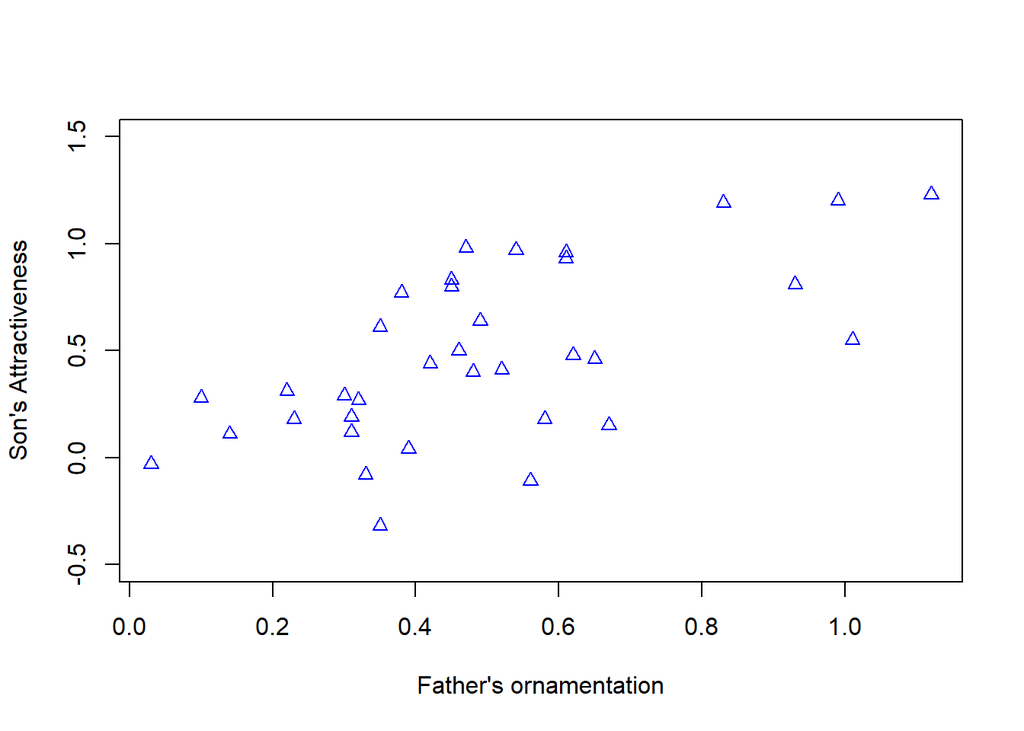

```r
# plot(X VAR, Y VAR, xlab="X LABEL", ylab="YLABEL", color="COLOR", pch=DOT_SIZE, ylim=c(MIN VALUE, MAX VALUE))
## ylim = Y limitation (axis scale)
plot(Guppies$father.ornament, Guppies$son.attract, xlab="Father's ornamentation", ylab="Son's Attractiveness", col="blue", pch=2, ylim=c(-0.5, 1.5))
```

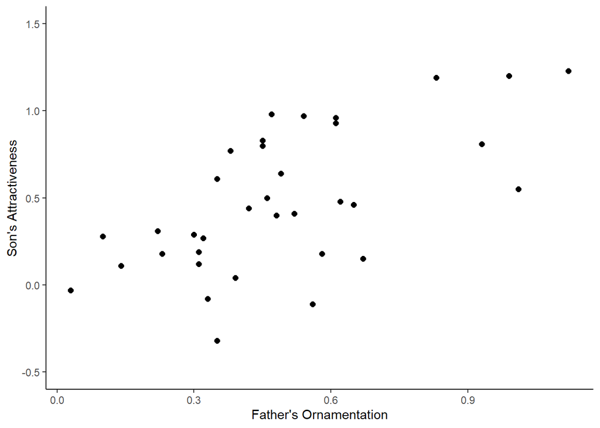

```r
# ggplot(DATAFRAMENAME, aes(x=X_VAR, y=Y_VAR))+
## geom_point = scatterplot+
## scale_y_continous --> Sets the scale of y axis
ggplot(Guppies, aes(x=father.ornament, y=son.attract))+
  geom_point(col="black", size=2)+
  scale_y_continuous(limits=c(-0.5,1.5))+
  labs(y="Son's Attractiveness",x="Father's Ornamentation")+
  theme_classic()
```

```r
# ?mean
# ?apply
```

Play with the code for both of these plots to see if you can figure out how to change the size, shape, and color of the plotting points.

> Write a sentence to describe what we learn from this plot.

### 2.2.b CDF plots

Now let’s make a cumulative density plot Shows where data is clustered

```r
#View first six lines of data
head(DesertBirds)
```

```
##            species count
## 1    Black Vulture    64
## 2   Turkey Vulture    23
## 3    Harris's Hawk     3
## 4  Red-tailed Hawk    16
## 5 American Kestrel     7
## 6   Gambel's Quail   148
```

```r
#Species column = Factor variable, count column = integer
str(DesertBirds)
```

```
## 'data.frame':    43 obs. of  2 variables:
##  $ species: Factor w/ 43 levels "American Kestrel",..: 4 39 23 36 1 17 37 43 31 22 ...
##  $ count  : int  64 23 3 16 7 148 7 625 135 1 ...
```

```r
summary(DesertBirds)
```

```
##                     species       count
##  American Kestrel       : 1   Min.   :  1.00
##  Ash-throated Flycatcher: 1   1st Qu.:  3.50
##  Bell's Vireo           : 1   Median : 18.00
##  Black Vulture          : 1   Mean   : 74.77
##  Black-chin. Hummingbird: 1   3rd Qu.:102.50
##  Black-tail. Gnatcatcher: 1   Max.   :625.00
##  (Other)                :37
```

```r
View(DesertBirds)

#rnorm generates random normal distribution
## length(DesertBirds$count) -> Number of rows in the DesertBirds dataset
norm_data <- rnorm(length(DesertBirds$count), mean=mean(DesertBirds$count), sd=sd(DesertBirds$count))
#?rnorm

head(norm_data)
```

```
## [1]  46.42676 -70.13881 -47.68415 -20.52255 -10.94341  29.67201
```

```r
head(DesertBirds$count)
```

```
## [1]  64  23   3  16   7 148
```

> Q. What did we just do with this function?

```r
# make a cdf based on the data

emp_cdf <- ecdf(DesertBirds$count)

# make a cdf of the normal sample

norm_cdf <- ecdf(norm_data)

# plot

plot(emp_cdf, col="red", main="CDF of Bird Counts Compared to Normal Distribution",
     xlab="Count", ylab="Cumulative relative frequency")+
  # Use lines to add more lines to the given plot
  lines(norm_cdf)
```

```
## integer(0)
```

```r
# add a legend
  legend(400, .2, c("Birds", "Normal Distribution"), col=c("red", "black"), pch=c(19,19))
```

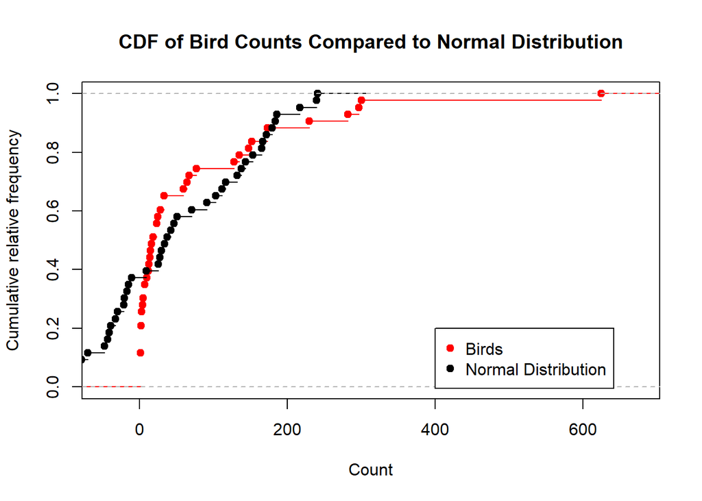

> Q. What can you learn from this plot about the distribution of desert bird counts?

Another way to compare the distribution of your data to a normal distribution is to use the qqnorm() function. Normal data should be in line with the qqline drawn.

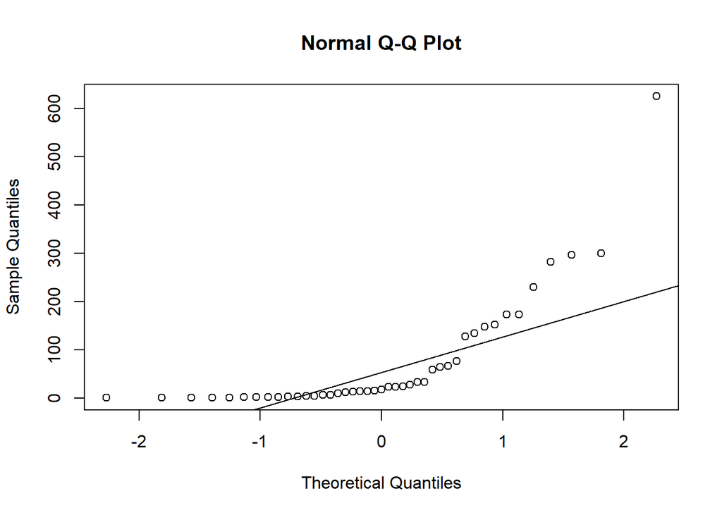

```r
## Quantile-quantile > Plots density of points by expected density of points
#Expect normal distribution to follow 1-1 line
qqnorm(DesertBirds$count)
qqline(DesertBirds$count)
```

### 2.2.c Line plots

If you have a time-series dataset, a line plot is a good way to visualize it. We can use the lynx data as an example:

```r
head(Lynx)
```

```
##   year pelts
## 1 1752  4009
## 2 1753  7179
## 3 1754  4198
## 4 1755  1444
## 5 1756   838
## 6 1757   631
```

```r
str(Lynx)
```

```
## 'data.frame':    68 obs. of  2 variables:
##  $ year : int  1752 1753 1754 1755 1756 1757 1758 1759 1760 1761 ...
##  $ pelts: int  4009 7179 4198 1444 838 631 917 1881 3842 5338 ...
```

```r
summary(Lynx)
```

```
##       year          pelts
##  Min.   :1752   Min.   : 116.0
##  1st Qu.:1769   1st Qu.: 986.8
##  Median :1786   Median :1551.5
##  Mean   :1786   Mean   :2137.3
##  3rd Qu.:1802   3rd Qu.:2858.8
##  Max.   :1819   Max.   :7179.0
```

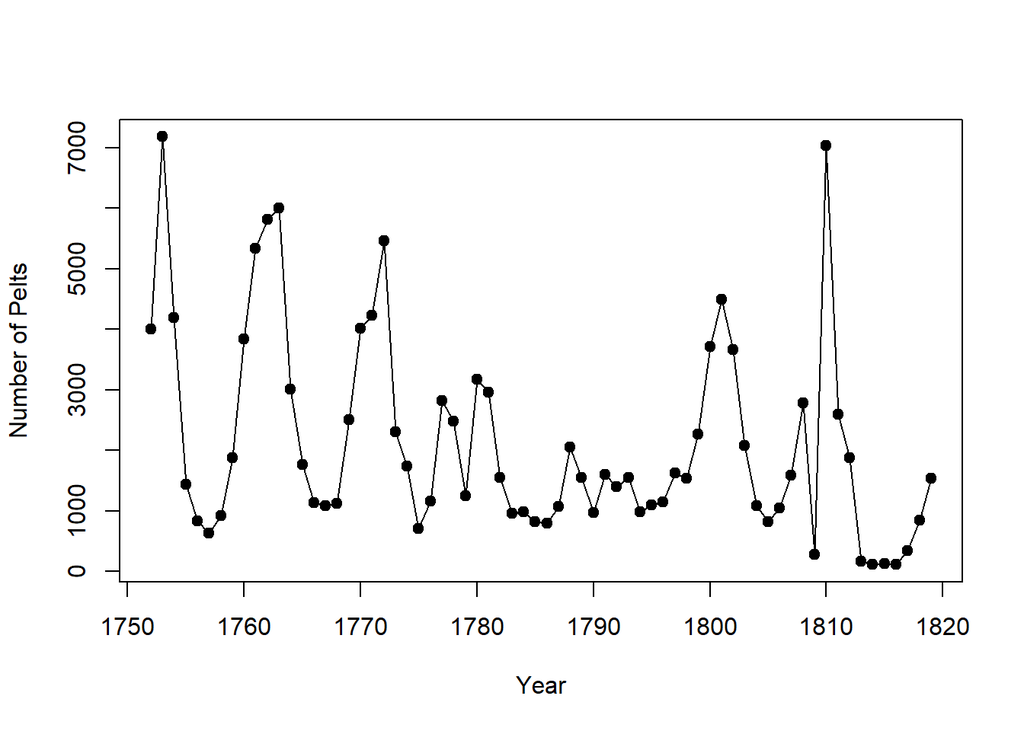

```
## integer(0)
```

```r
plot(Lynx$year, Lynx$pelts, pch=19, xlab="Year", ylab="Number of Pelts")+
  lines(Lynx$year, Lynx$pelts)
```

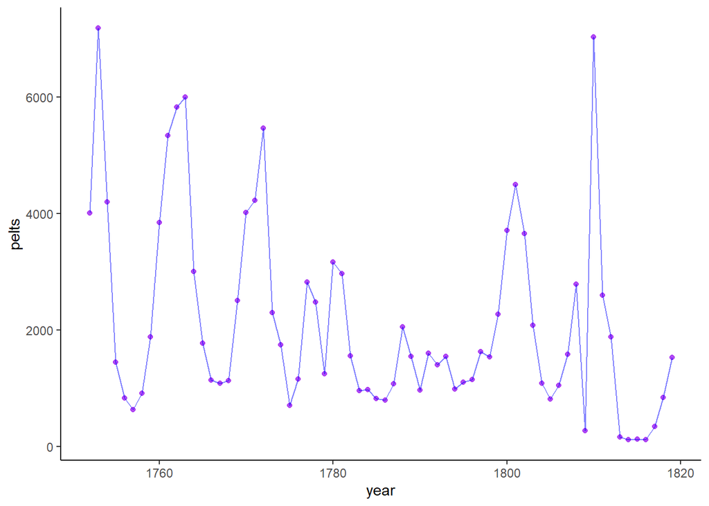

```r
ggplot(Lynx, aes(x=year, y=pelts))+
  geom_point(color="purple", alpha=0.8)+
  geom_line(color="blue", alpha=0.5)+
  theme_classic()
```

# 3. Visualizing many variables

We’re going to use the iris dataset here. We want to look at the distribution of different flower measurements across several different iris species.

```r
head(iris)
```

```
##   Sepal.Length Sepal.Width Petal.Length Petal.Width Species
## 1          5.1         3.5          1.4         0.2  setosa
## 2          4.9         3.0          1.4         0.2  setosa
## 3          4.7         3.2          1.3         0.2  setosa
## 4          4.6         3.1          1.5         0.2  setosa
## 5          5.0         3.6          1.4         0.2  setosa
## 6          5.4         3.9          1.7         0.4  setosa
```

```r
str(iris)
```

```
## 'data.frame':    150 obs. of  5 variables:
##  $ Sepal.Length: num  5.1 4.9 4.7 4.6 5 5.4 4.6 5 4.4 4.9 ...
##  $ Sepal.Width : num  3.5 3 3.2 3.1 3.6 3.9 3.4 3.4 2.9 3.1 ...
##  $ Petal.Length: num  1.4 1.4 1.3 1.5 1.4 1.7 1.4 1.5 1.4 1.5 ...
##  $ Petal.Width : num  0.2 0.2 0.2 0.2 0.2 0.4 0.3 0.2 0.2 0.1 ...
##  $ Species     : Factor w/ 3 levels "setosa","versicolor",..: 1 1 1 1 1 1 1 1 1 1 ...
```

```r
summary(iris)
```

```
##   Sepal.Length    Sepal.Width     Petal.Length    Petal.Width
##  Min.   :4.300   Min.   :2.000   Min.   :1.000   Min.   :0.100
##  1st Qu.:5.100   1st Qu.:2.800   1st Qu.:1.600   1st Qu.:0.300
##  Median :5.800   Median :3.000   Median :4.350   Median :1.300
##  Mean   :5.843   Mean   :3.057   Mean   :3.758   Mean   :1.199
##  3rd Qu.:6.400   3rd Qu.:3.300   3rd Qu.:5.100   3rd Qu.:1.800
##  Max.   :7.900   Max.   :4.400   Max.   :6.900   Max.   :2.500
##        Species
##  setosa    :50
##  versicolor:50
##  virginica :50
##
##
##
```

```r
View(iris)

iris$Petal.Width <- iris$Petal.Width + 2
str(iris)
```

```
## 'data.frame':    150 obs. of  5 variables:
##  $ Sepal.Length: num  5.1 4.9 4.7 4.6 5 5.4 4.6 5 4.4 4.9 ...
##  $ Sepal.Width : num  3.5 3 3.2 3.1 3.6 3.9 3.4 3.4 2.9 3.1 ...
##  $ Petal.Length: num  1.4 1.4 1.3 1.5 1.4 1.7 1.4 1.5 1.4 1.5 ...
##  $ Petal.Width : num  2.2 2.2 2.2 2.2 2.2 2.4 2.3 2.2 2.2 2.1 ...
##  $ Species     : Factor w/ 3 levels "setosa","versicolor",..: 1 1 1 1 1 1 1 1 1 1 ...
```

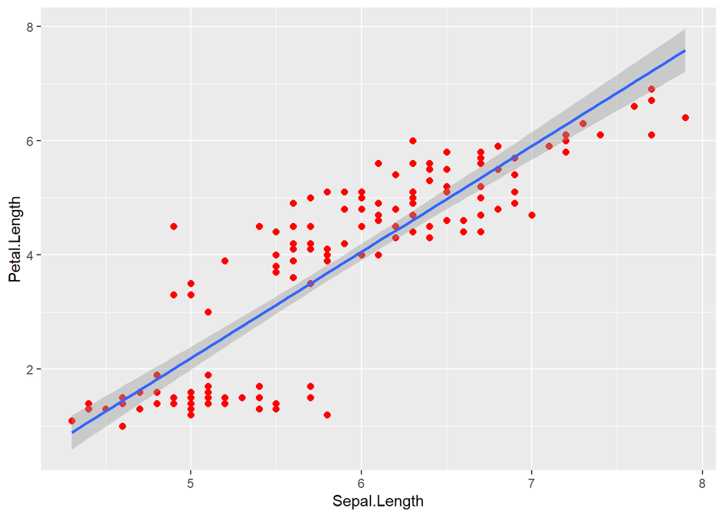

```r
iris$ratio <- iris$Sepal.Length/iris$Sepal.Width

# first, let's plot sepal and petal length and add a linear model line
# geom_smooth plots a confidence interval for the line

ggplot(iris, aes(x = Sepal.Length, y = Petal.Length))+
  geom_point(col="red", size=2)+
  geom_smooth(method="lm")
```

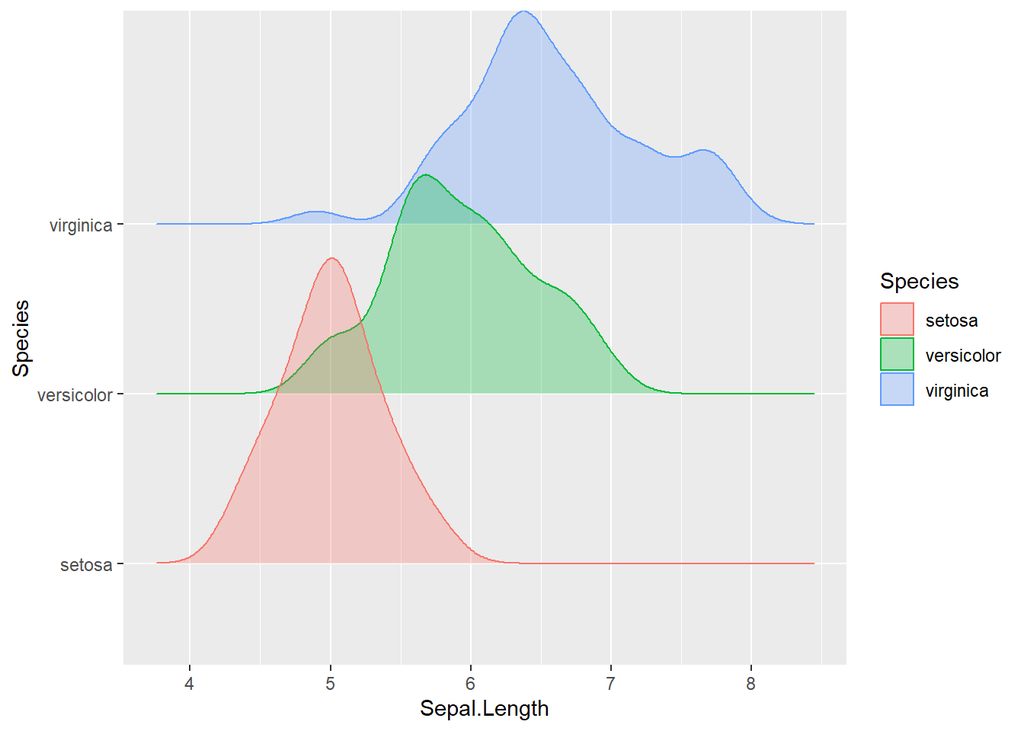

```r
# now compare the distribution of sepal lengths across the different iris species
##ggridges plots a series of density plots
ggplot(iris, aes(x=Sepal.Length, y=Species))+ # notice how x and y are swapped to set up a ggridges plot
  geom_density_ridges(aes(color=Species,fill=Species), alpha=0.3)
```

```r
#what if we wanted to create a new column in the data fram for petal area?
iris$Petal.Area = iris$Petal.Length * iris$Petal.Width
View(iris)
```

> Q. What do the arguments color, fill, and alpha do? What is the difference between defining color within the aes() function and outside it?

> Q. Now create another ridge plot that compares another variable across the three species

Finally, a great way to visualize relationships between many variables all at once is to create a big scatterplot matrix. You can do this easily by using a function from the “car” package.

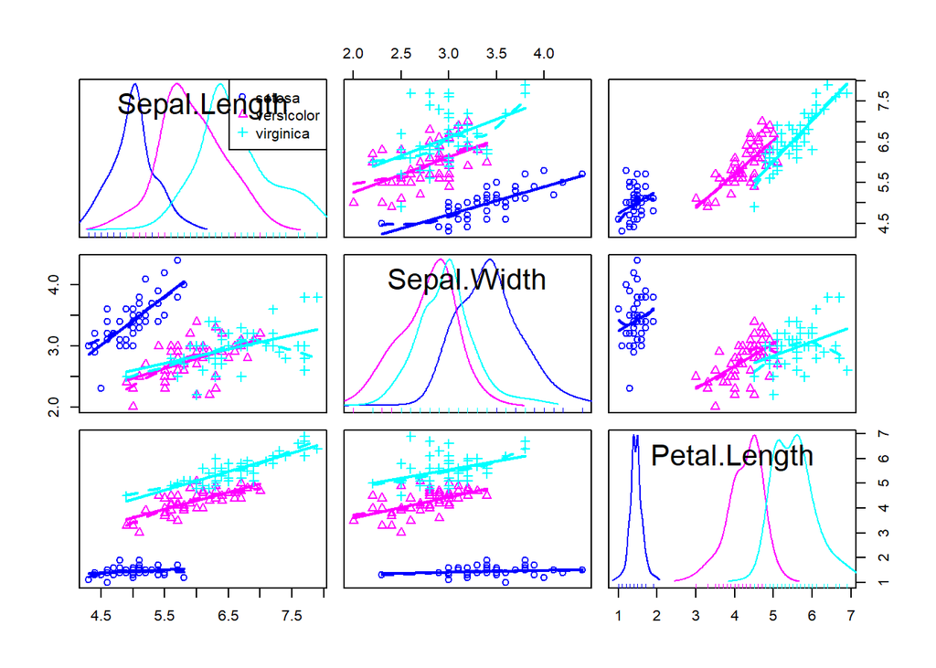

```r
scatterplotMatrix(~ Sepal.Length + Sepal.Width + Petal.Length | Species, data=iris)
```

```r
# Look at how this function is created: we specified the variables of interest on the left hand side, and then specified a grouping variable to color the points by species on the right hand side.
```

> Q. Look carefully at this scatterplot matrix. How would you describe the differences between the different flower species?

# 4 Manipulating Datasets

What if we want to get information about different categories of data within the same dataset? Summarizing the whole dataset won’t work, so we need a way to group the data by levels of a factor, for example. That’s where dplyr comes in! The various functions within dplyr allow us to manipulate data easily.

```r
#using the iris dataset
#use the group_by and summarize function to find the mean and standard deviation of petal length for each species
sum_iris <- iris %>%
  group_by(Species) %>%
  summarize(mean.width=mean(Sepal.Length),sd.width=sd(Sepal.Length))

#try this for Sepal Length!
##prints out value in third row, second column
iris[3,2]
```

```
## [1] 3.2
```

```r
#Take mean from rows 1-3, in the second column
mean(iris[1:3, 2])
```

```
## [1] 3.233333
```

```r
#Change value
iris[5,4] <- 5
head(iris)
```

```
##   Sepal.Length Sepal.Width Petal.Length Petal.Width Species    ratio Petal.Area
## 1          5.1         3.5          1.4         2.2  setosa 1.457143       3.08
## 2          4.9         3.0          1.4         2.2  setosa 1.633333       3.08
## 3          4.7         3.2          1.3         2.2  setosa 1.468750       2.86
## 4          4.6         3.1          1.5         2.2  setosa 1.483871       3.30
## 5          5.0         3.6          1.4         5.0  setosa 1.388889       3.08
## 6          5.4         3.9          1.7         2.4  setosa 1.384615       4.08
```

```r
#what about merging two datasets?

temperature <- read.csv("Site_Temps.csv")
names(temperature)[1] = "Site"
windspeed <- read.csv("Site_Windspeed.csv")
names(windspeed)[1] = "Site"

head(temperature)
```

```
##   Site Temperature
## 1    1          23
## 2    2          25
## 3    3          18
## 4    4          15
## 5    5          22
## 6    6          21
```

```r
str(temperature)
```

```
## 'data.frame':    40 obs. of  2 variables:
##  $ Site       : int  1 2 3 4 5 6 7 8 9 10 ...
##  $ Temperature: int  23 25 18 15 22 21 19 17 22 23 ...
```

```r
head(windspeed)
```

```
##   Site Windspeed
## 1    1         0
## 2    2         0
## 3    3         0
## 4    4         5
## 5    5         0
## 6    6         6
```

```r
str(windspeed)
```

```
## 'data.frame':    40 obs. of  2 variables:
##  $ Site     : int  1 2 3 4 5 6 7 8 9 10 ...
##  $ Windspeed: int  0 0 0 5 0 6 9 1 7 10 ...
```

```r
#use the merge function to join by the common column name
new_data <- merge(temperature,windspeed, by="Site")
new_data
```

```
##    Site Temperature Windspeed
## 1     1          23         0
## 2     2          25         0
## 3     3          18         0
## 4     4          15         5
## 5     5          22         0
## 6     6          21         6
## 7     7          19         9
## 8     8          17         1
## 9     9          22         7
## 10   10          23        10
## 11   11          23         8
## 12   12          17         0
## 13   13          18         0
## 14   14          22         5
```

[output cut: 26 more lines]

```r
#what if we want to convert temperatures to celsius
#one way to do this is using the lapply function
#make a function to convert celsius to fahrenheight
celsius_to_fahrenheit <- function(temp_C) {
  temp_F <- (temp_C * 9 / 5) + 32
  return(temp_F)
}

#use lapply to convert each row in the column
## hasn not actually changed the values in the dataset
lapply(new_data$Temperature, celsius_to_fahrenheit)
```

```
## [[1]]
## [1] 73.4
##
## [[2]]
## [1] 77
##
## [[3]]
## [1] 64.4
##
## [[4]]
## [1] 59
##
## [[5]]
## [1] 71.6
##
## [[6]]
## [1] 69.8
##
## [[7]]
## [1] 66.2
##
## [[8]]
## [1] 62.6
##
## [[9]]
## [1] 71.6
##
## [[10]]
## [1] 73.4
##
## [[11]]
## [1] 73.4
##
## [[12]]
## [1] 62.6
##
## [[13]]
## [1] 64.4
##
## [[14]]
```

[output cut: 64 more lines]

```
##
## [[36]]
## [1] 68
##
## [[37]]
## [1] 69.8
##
## [[38]]
## [1] 71.6
##
## [[39]]
## [1] 71.6
##
## [[40]]
## [1] 71.6
```

```r
#or if we want to change the actual values within the dataframe:
new_data$Temperature <- celsius_to_fahrenheit(new_data$Temperature)
```